# Jawaban Latihan Pertemuan 4 - Pembangkitan AR, MA, dan ARMA

2026-09-17

# 1 1. Proses MA(2)

## 1.1 1.1 Model

Model MA(2) dengan `theta1 = 0.4` dan `theta2 = 0.6` dituliskan sebagai

$$Y_t=e_t+0.4e_{t-1}+0.6e_{t-2}.$$

Model ini merupakan perluasan dari bentuk umum MA, yaitu nilai saat ini dibentuk dari white noise saat ini dan white noise pada beberapa periode sebelumnya.

## 1.2 1.2 Pembangkitan manual

```r
set.seed(1234)
wn <- rnorm(n)

ma2 <- wn[1:2]

for(i in 3:n){
  ma2[i] <- wn[i] +
            0.4 * wn[i - 1] +
            0.6 * wn[i - 2]
}

head(ma2)
```

```
## [1] -1.2070657  0.2774292  0.4711734 -1.7454637  0.1415103 -0.7297129
```

## 1.3 1.3 Pembangkitan dengan `arima.sim()`

```r
ma2_sim <- arima.sim(
  list(order = c(0, 0, 2), ma = c(0.4, 0.6)),
  n = n
)

head(ma2_sim)
```

```
## Time Series:
## Start = 1
## End = 6
## Frequency = 1
## [1] -0.90871426  0.36606956  0.31989275 -0.03369264 -0.74980954  1.02322487
```

Nilai koefisiennya adalah 0.4 dan 0.6.

## 1.4 1.4 Plot time series

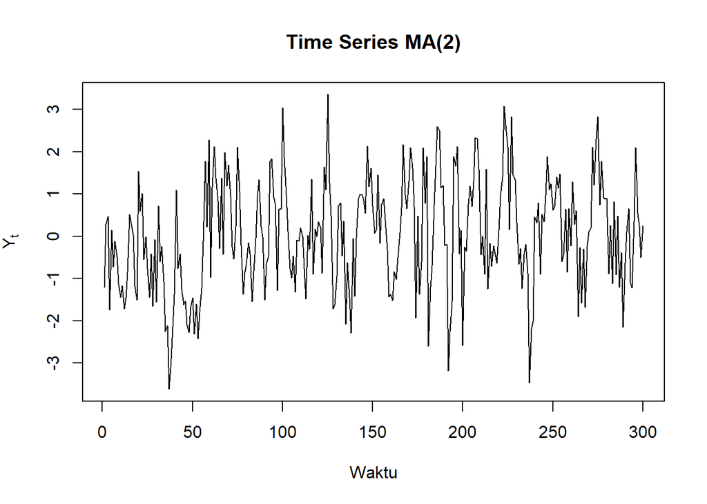

```r
ts.plot(ma2,
         main = "Time Series MA(2)",
         ylab = expression(Y[t]),
         xlab = "Waktu")
```

**Interpretasi:**

Data terlihat naik-turun di sekitar nilai yang relatif tetap dan tidak menunjukkan tren yang jelas. Jadi, dari plot ini data dapat dianggap stasioner.

## 1.5 1.5 Plot ACF

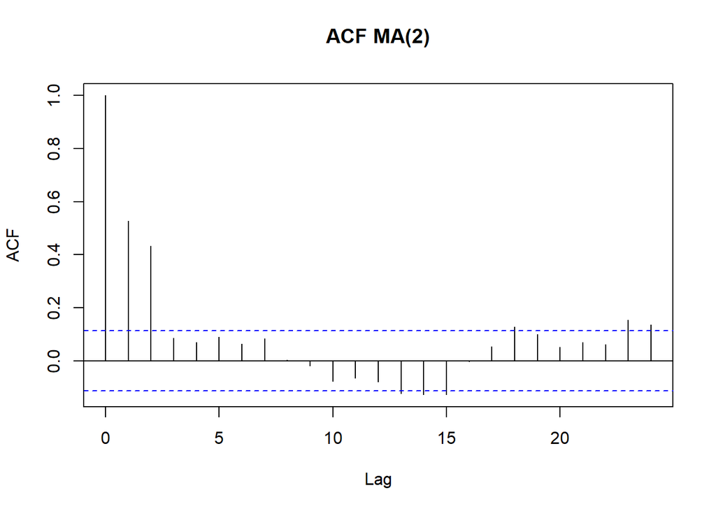

```r
acf(ma2,
    main = "ACF MA(2)")
```

**Interpretasi:**

Pada MA(2), ACF biasanya terlihat sampai lag 2 lalu mendekati nol. Ini sesuai dengan ciri MA(2).

## 1.6 1.6 Plot PACF

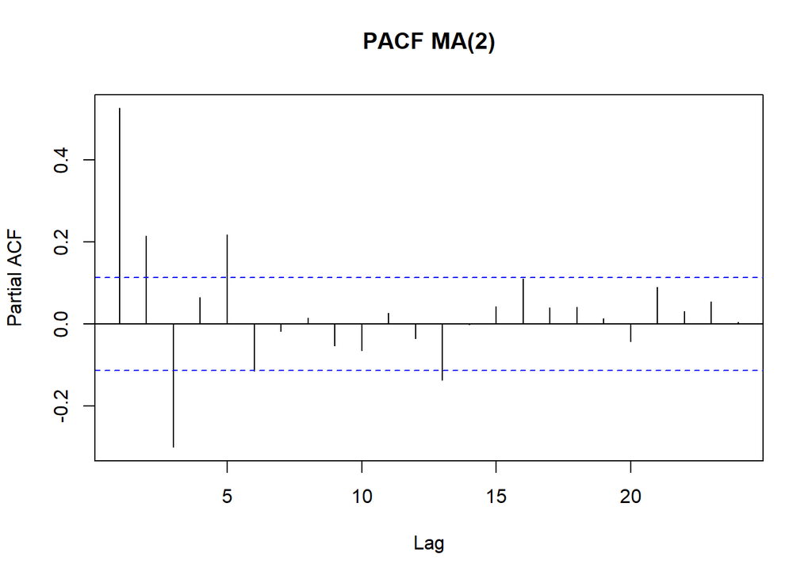

```r
pacf(ma2,
     main = "PACF MA(2)")
```

**Interpretasi:**

PACF cenderung **tails off**, yaitu nilainya turun secara bertahap dan tidak berhenti tajam pada lag tertentu.

## 1.7 1.7 Plot EACF

```r
TSA::eacf(ma2)
```

```
## AR/MA
##   0 1 2 3 4 5 6 7 8 9 10 11 12 13
## 0 x x o o o o o o o o o  o  x  x
## 1 x x x o o o o o o o o  o  o  o
## 2 x x x x o o o o o o o  o  o  o
## 3 x x x x x o o o o o o  o  o  o
## 4 x x x x x o o o o o o  o  o  o
## 5 x x x x x o x o o o o  o  o  o
## 6 x x x o x o o x o o o  o  o  o
## 7 x o x o x o o x o o o  o  o  o
```

**Interpretasi:**

EACF membantu melihat ordo model. Untuk MA(2), pola yang dicari mengarah ke **AR(0), MA(2)**.

## 1.8 1.8 Scatterplot antar-lag

### 1.8.1 $Y_t$ dengan $Y_{t-1}$

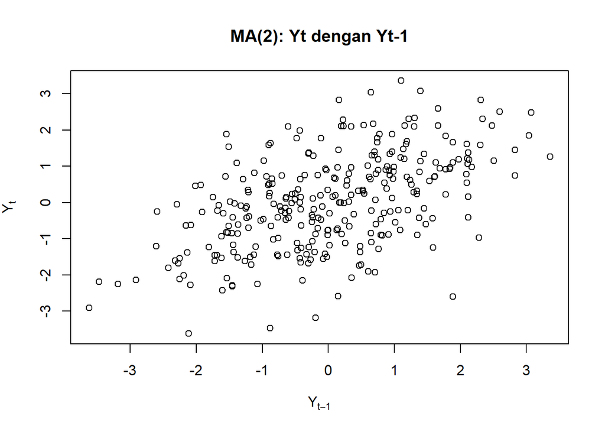

```r
yt_ma2_1 <- ma2[2:n]
yt1_ma2 <- ma2[1:(n-1)]

plot(yt1_ma2, yt_ma2_1,
     xlab = expression(Y[t-1]),
     ylab = expression(Y[t]),
     main = "MA(2): Yt dengan Yt-1")
```

### 1.8.2 $Y_t$ dengan $Y_{t-2}$

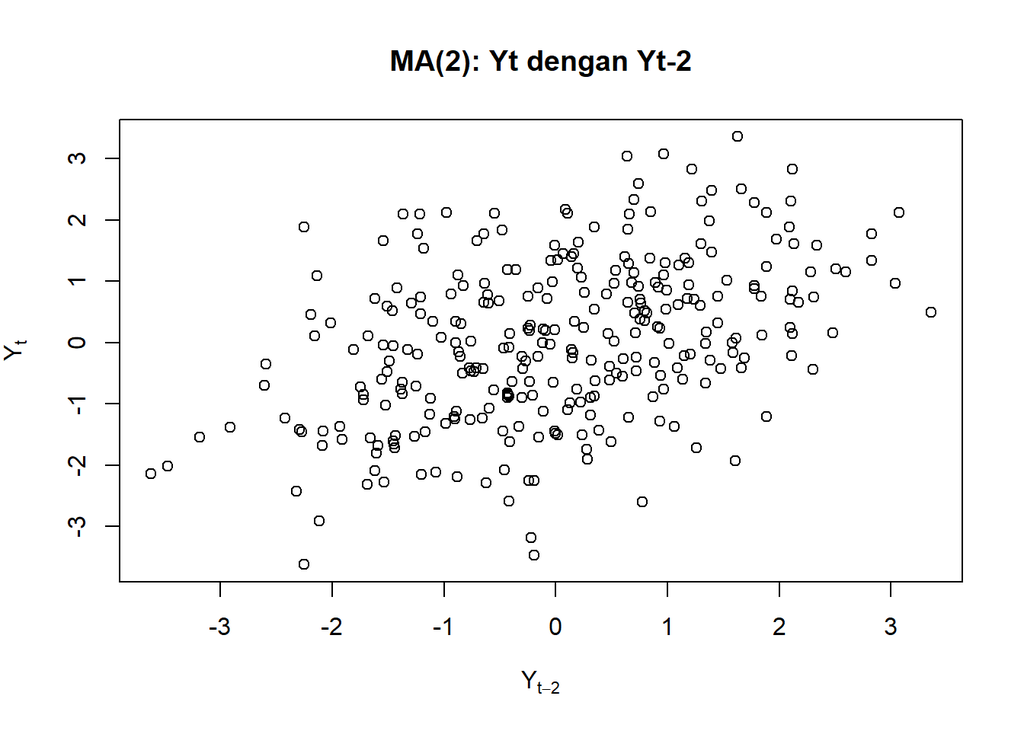

```r
yt_ma2_2 <- ma2[3:n]
yt2_ma2 <- ma2[1:(n-2)]

plot(yt2_ma2, yt_ma2_2,
     xlab = expression(Y[t-2]),
     ylab = expression(Y[t]),
     main = "MA(2): Yt dengan Yt-2")
```

### 1.8.3 $Y_t$ dengan $Y_{t-3}$

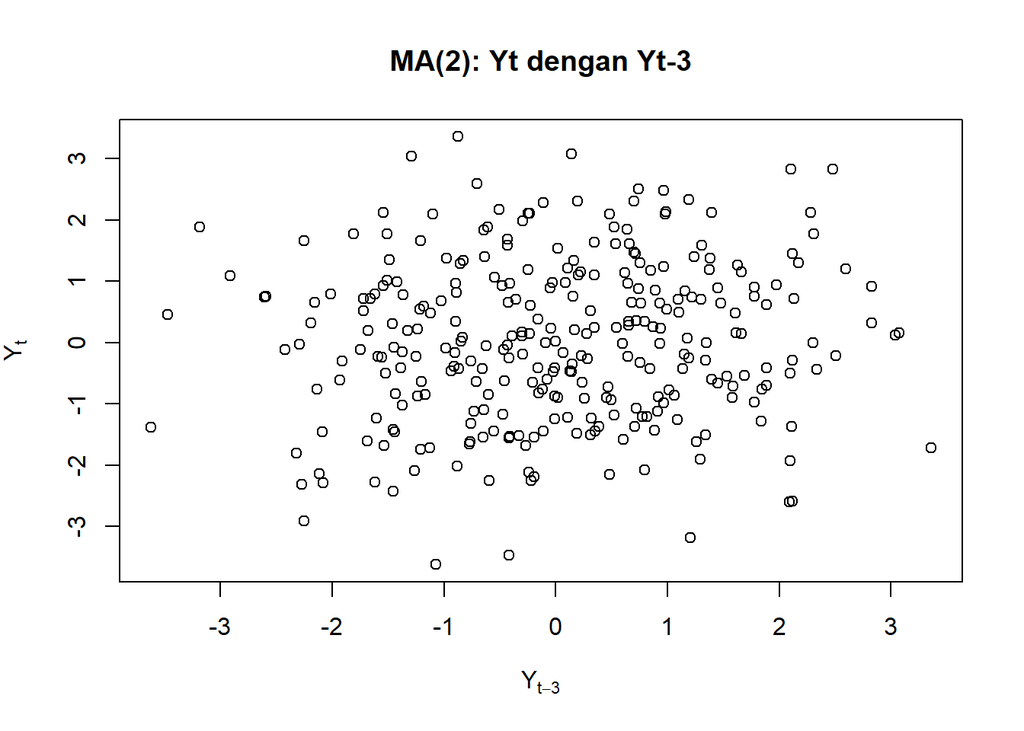

```r
yt_ma2_3 <- ma2[4:n]
yt3_ma2 <- ma2[1:(n-3)]

plot(yt3_ma2, yt_ma2_3,
     xlab = expression(Y[t-3]),
     ylab = expression(Y[t]),
     main = "MA(2): Yt dengan Yt-3")
```

**Interpretasi:**

Scatterplot dipakai untuk melihat hubungan $Y_t$ dengan nilai sebelumnya. Pada MA(2), hubungan masih terlihat pada lag 1 dan lag 2, sedangkan pada lag 3 seharusnya sudah sangat lemah.

## 1.9 1.9 Autokorelasi hasil bangkitan

```r
rho_ma2_sim <- c(
  cor(yt_ma2_1, yt1_ma2),
  cor(yt_ma2_2, yt2_ma2),
  cor(yt_ma2_3, yt3_ma2)
)

rho_ma2_sim
```

```
## [1] 0.52746057 0.43392925 0.08555282
```

**Interpretasi:**

`cor()` menghitung korelasi antara $Y_t$ dan nilai pada lag tertentu. Hasil simulasi tidak harus sama persis dengan teori, tetapi biasanya polanya mendekati.

## 1.10 1.10 Autokorelasi teoritis MA(2)

Untuk MA(2), dengan

$$Y_t=e_t+\theta_1e_{t-1}+\theta_2e_{t-2},$$

autokorelasi yang digunakan adalah

$$\rho_1=\frac{\theta_1(1+\theta_2)}{1+\theta_1^2+\theta_2^2},$$

$$\rho_2=\frac{\theta_2}{1+\theta_1^2+\theta_2^2},$$

dan

$$\rho_k=0,\qquad k>2.$$

```r
den_ma2 <- 1 + 0.4^2 + 0.6^2
rho1_ma2 <- 0.4 * (1 + 0.6) / den_ma2
rho2_ma2 <- 0.6 / den_ma2
rho3_ma2 <- 0

rho_ma2_teori <- c(rho1_ma2, rho2_ma2, rho3_ma2)

round(rho_ma2_teori, 4)
```

```
## [1] 0.4211 0.3947 0.0000
```

**Interpretasi:**

Secara teori, MA(2) masih memiliki autokorelasi pada lag 1 dan 2. Pada lag 3 nilainya 0.

## 1.11 1.11 Perbandingan autokorelasi MA(2)

```r
data.frame(
  Lag = 1:3,
  Bangkitan = round(rho_ma2_sim, 4),
  Teoritis = round(rho_ma2_teori, 4)
)
```

```
##   Lag Bangkitan Teoritis
## 1   1    0.5275   0.4211
## 2   2    0.4339   0.3947
## 3   3    0.0856   0.0000
```

**Interpretasi:**

Nilai dari simulasi seharusnya mendekati nilai teori. Perbedaan kecil masih wajar karena data dibuat secara acak.

# 2 2. Proses AR(2)

## 2.1 2.1 Model

Model AR(2) dengan `phi1 = 0.5` dan `phi2 = 0.2` adalah

$$Y_t=e_t+0.5Y_{t-1}+0.2Y_{t-2}.$$

Bentuk ini mengikuti bentuk umum AR, yaitu nilai sekarang dipengaruhi oleh nilai-nilai deret waktu sebelumnya.

## 2.2 2.2 Pembangkitan manual

```r
set.seed(1234)
wn <- rnorm(n)

ar2 <- c(1, 2)

for(i in 3:n){
  ar2[i] <- wn[i] +
            0.5 * ar2[i - 1] +
            0.2 * ar2[i - 2]
}

head(ar2)
```

```
## [1]  1.0000000  2.0000000  2.2844412 -0.8034771  0.4842744  0.5874977
```

Nilai 0.5 dan 0.2 adalah koefisien yang digunakan untuk $Y_{t-1}$ dan $Y_{t-2}$.

## 2.3 2.3 Pembangkitan dengan `arima.sim()`

```r
ar2_sim <- arima.sim(
  list(order = c(2, 0, 0), ar = c(0.5, 0.2)),
  n = n
)

head(ar2_sim)
```

```
## Time Series:
## Start = 1
## End = 6
## Frequency = 1
## [1] -1.5119879  0.1462264 -1.1819699  0.5647431 -0.6030655  0.1038860
```

**Interpretasi:**

`order = c(2, 0, 0)` berarti model yang dibuat adalah AR(2).

## 2.4 2.4 Plot time series

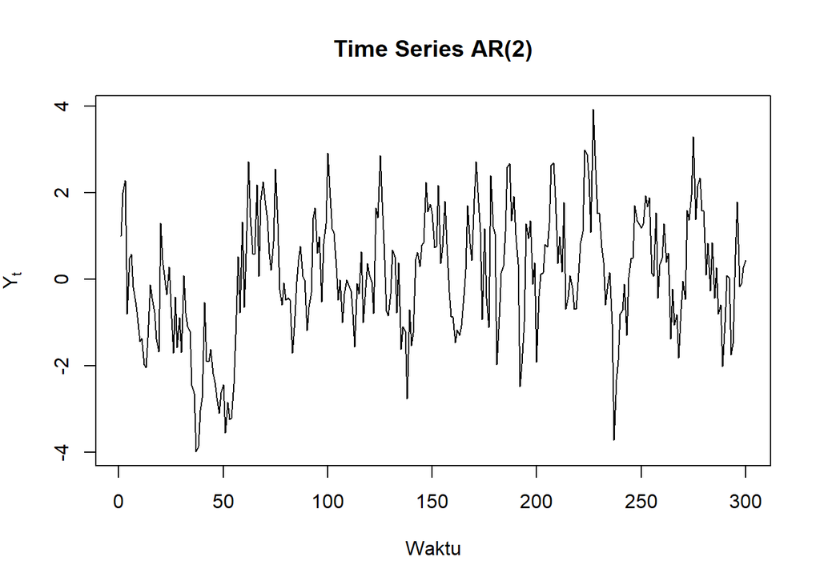

```r
ts.plot(ar2,
         main = "Time Series AR(2)",
         ylab = expression(Y[t]),
         xlab = "Waktu")
```

**Interpretasi:**

Data berfluktuasi di sekitar nilai yang relatif tetap dan tidak menunjukkan tren yang jelas. Jadi, dari plot ini data dapat dianggap stasioner.

## 2.5 2.5 Plot ACF

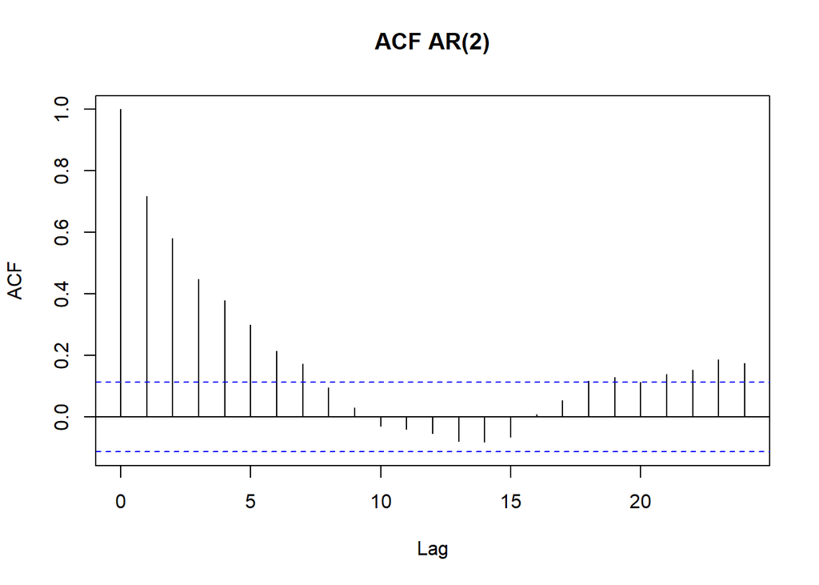

```r
acf(ar2,
    main = "ACF AR(2)")
```

**Interpretasi:**

Pada AR(2), ACF biasanya **tails off**, sehingga korelasi berkurang secara bertahap dan tidak langsung menjadi nol.

## 2.6 2.6 Plot PACF

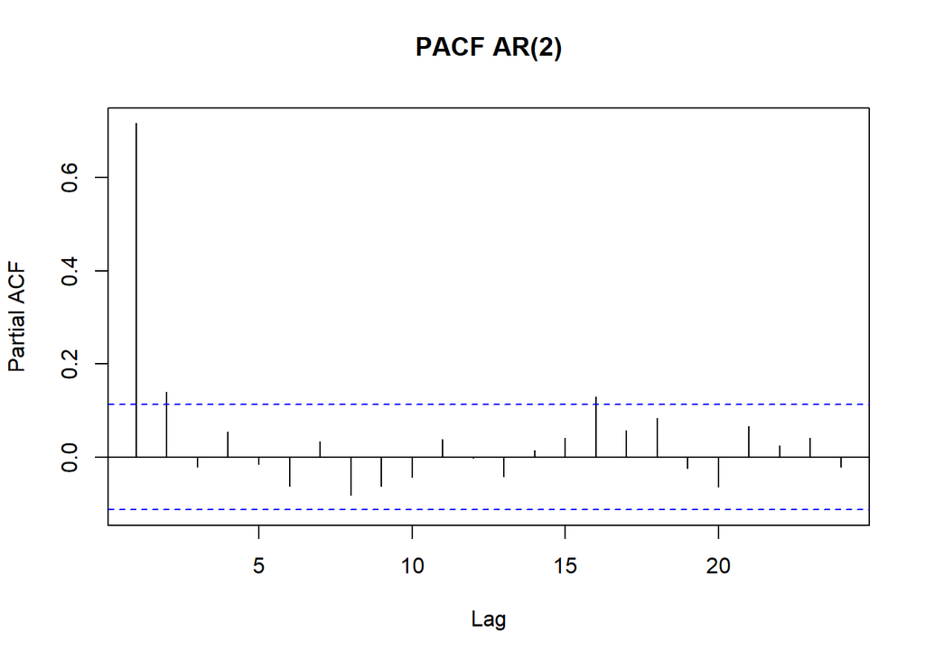

```r
pacf(ar2,
     main = "PACF AR(2)")
```

**Interpretasi:**

Pada AR(2), PACF diharapkan **cut off setelah lag 2**. Ini sesuai dengan ordo AR yang digunakan.

## 2.7 2.7 Plot EACF

```r
TSA::eacf(ar2)
```

```
## AR/MA
##   0 1 2 3 4 5 6 7 8 9 10 11 12 13
## 0 x x x x x x x o o o o  o  o  o
## 1 x o o o o o o o o o o  o  o  o
## 2 x o o o o o o o o o o  o  o  o
## 3 x x o o o o o o o o o  o  o  o
## 4 x x o o o o o o o o o  o  o  o
## 5 x x x x o o x o o o o  o  o  o
## 6 x x x x o o o o o o o  o  o  o
## 7 x x x o x x o o o o o  o  o  o
```

**Interpretasi:**

## 2.8 2.8 Scatterplot antar-lag

### 2.8.1 $Y_t$ dengan $Y_{t-1}$

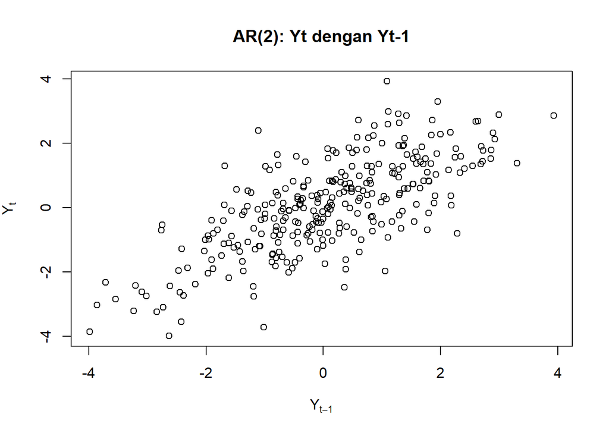

```r
yt_ar2_1 <- ar2[2:n]
yt1_ar2 <- ar2[1:(n-1)]

plot(yt1_ar2, yt_ar2_1,
     xlab = expression(Y[t-1]),
     ylab = expression(Y[t]),
     main = "AR(2): Yt dengan Yt-1")
```

### 2.8.2 $Y_t$ dengan $Y_{t-2}$

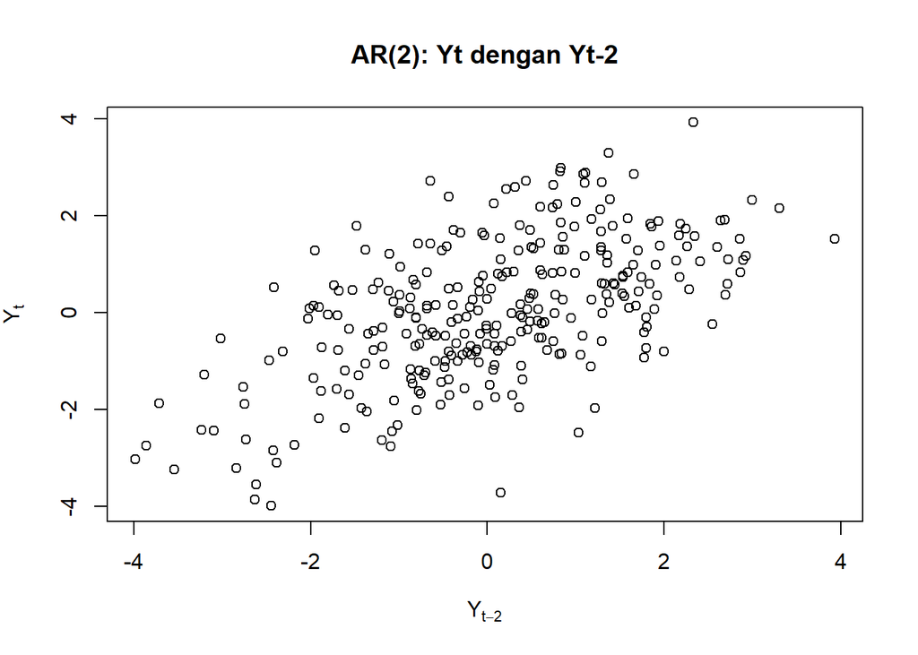

```r
yt_ar2_2 <- ar2[3:n]
yt2_ar2 <- ar2[1:(n-2)]

plot(yt2_ar2, yt_ar2_2,
     xlab = expression(Y[t-2]),
     ylab = expression(Y[t]),
     main = "AR(2): Yt dengan Yt-2")
```

### 2.8.3 $Y_t$ dengan $Y_{t-3}$

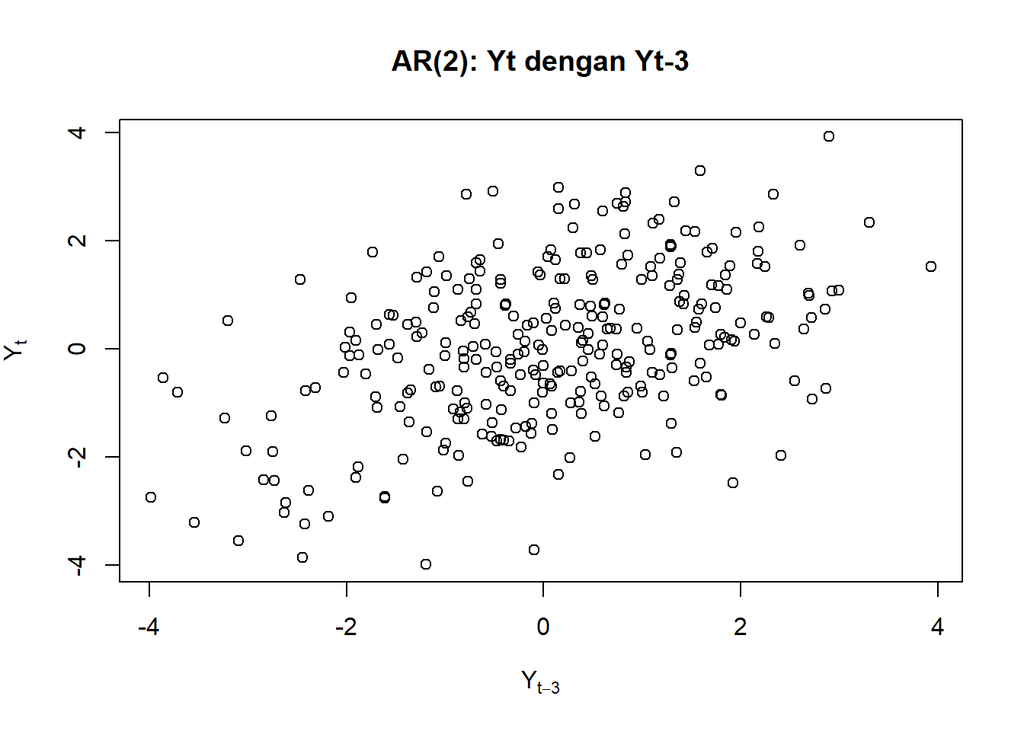

```r
yt_ar2_3 <- ar2[4:n]
yt3_ar2 <- ar2[1:(n-3)]

plot(yt3_ar2, yt_ar2_3,
     xlab = expression(Y[t-3]),
     ylab = expression(Y[t]),
     main = "AR(2): Yt dengan Yt-3")
```

**Interpretasi:**

Karena koefisien AR bernilai positif, hubungan dengan lag 1 dan lag 2 cenderung positif. Hubungan pada lag 3 juga masih bisa muncul karena pengaruh AR berlanjut.

## 2.9 2.9 Autokorelasi hasil bangkitan

```r
rho_ar2_sim <- c(
  cor(yt_ar2_1, yt1_ar2),
  cor(yt_ar2_2, yt2_ar2),
  cor(yt_ar2_3, yt3_ar2)
)

rho_ar2_sim
```

```
## [1] 0.7173171 0.5836665 0.4522274
```

**Interpretasi:**

Nilai korelasi menunjukkan seberapa kuat $Y_t$ berhubungan dengan nilai sebelumnya. Pada AR(2), korelasi tidak langsung menjadi nol setelah lag 2.

## 2.10 2.10 Autokorelasi teoritis AR(2)

Untuk AR(2), digunakan hubungan rekursif

$$\rho_1=\frac{\phi_1}{1-\phi_2},$$

$$\rho_2=\phi_1\rho_1+\phi_2,$$

dan untuk lag berikutnya

$$\rho_k=\phi_1\rho_{k-1}+\phi_2\rho_{k-2}.$$

```r
rho1_ar2 <- 0.5 / (1 - 0.2)
rho2_ar2 <- 0.5 * rho1_ar2 + 0.2
rho3_ar2 <- 0.5 * rho2_ar2 + 0.2 * rho1_ar2

rho_ar2_teori <- c(rho1_ar2, rho2_ar2, rho3_ar2)

round(rho_ar2_teori, 4)
```

```
## [1] 0.6250 0.5125 0.3812
```

**Interpretasi:**

Nilai teoritis semuanya positif dan semakin kecil saat lag bertambah. Artinya, pengaruh nilai masa lalu makin lemah tetapi masih ada.

## 2.11 2.11 Perbandingan autokorelasi AR(2)

```r
data.frame(
  Lag = 1:3,
  Bangkitan = round(rho_ar2_sim, 4),
  Teoritis = round(rho_ar2_teori, 4)
)
```

```
##   Lag Bangkitan Teoritis
## 1   1    0.7173   0.6250
## 2   2    0.5837   0.5125
## 3   3    0.4522   0.3812
```

**Interpretasi:**

Nilai autokorelasi hasil simulasi diharapkan mendekati nilai teoritis. Selisih kecil merupakan variasi yang wajar dari data hasil bangkitan.

# 3 3. Proses ARMA(2,2)

## 3.1 3.1 Model

Model ARMA(2,2) dengan

$$\phi_1=0.5,\quad \phi_2=0.2,$$

$$\theta_1=0.4,\quad \theta_2=0.6$$

adalah

$$Y_t=0.5Y_{t-1}+0.2Y_{t-2}+0.4e_{t-1}+0.6e_{t-2}+e_t.$$

Model ini menggabungkan komponen AR dan MA.

## 3.2 3.2 Pembangkitan manual

```r
set.seed(1234)
wn <- rnorm(n)

arma22 <- wn[1:2]

for(i in 3:n){
  arma22[i] <- 0.5 * arma22[i - 1] +
               0.2 * arma22[i - 2] +
               0.4 * wn[i - 1] +
               0.6 * wn[i - 2] +
               wn[i]
}

head(arma22)
```

```
## [1] -1.2070657  0.2774292  0.3684749 -1.5057404 -0.5376649 -1.2996934
```

**Interpretasi sintaks:**

Bagian `0.5 * arma22[i - 1] + 0.2 * arma22[i - 2]` adalah komponen AR. Bagian `0.4 * wn[i - 1] + 0.6 * wn[i - 2]` adalah komponen MA. Keduanya kemudian ditambah dengan white noise saat ini.

## 3.3 3.3 Pembangkitan dengan `arima.sim()`

```r
arma22_sim <- arima.sim(
  list(
    order = c(2, 0, 2),
    ar = c(0.5, 0.2),
    ma = c(0.4, 0.6)
  ),
  n = n
)

head(arma22_sim)
```

```
## Time Series:
## Start = 1
## End = 6
## Frequency = 1
## [1] -2.0296273  0.1804874 -1.0857429  0.2019685  0.5101006  0.3116648
```

**Interpretasi:**

`order = c(2, 0, 2)` berarti model yang dibuat adalah ARMA(2,2). Koefisien AR dan MA dimasukkan pada `ar` dan `ma`.

## 3.4 3.4 Plot time series

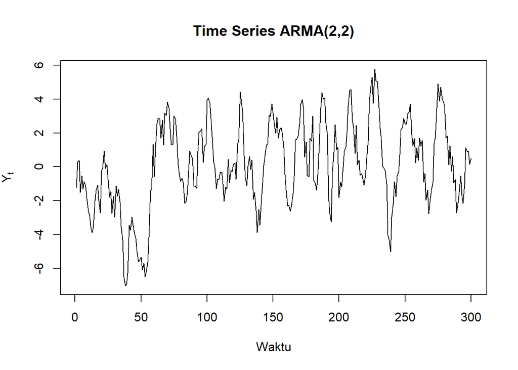

```r
ts.plot(arma22,
         main = "Time Series ARMA(2,2)",
         ylab = expression(Y[t]),
         xlab = "Waktu")
```

**Interpretasi:**

Data berfluktuasi pada level yang relatif tetap dan tidak menunjukkan tren yang jelas. Jadi, secara visual data dapat dianggap stasioner.

## 3.5 3.5 Plot ACF

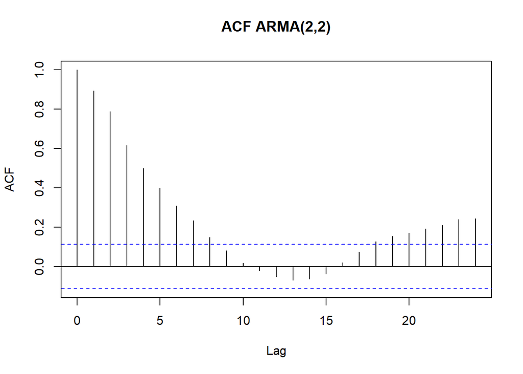

```r
acf(arma22,
    main = "ACF ARMA(2,2)")
```

**Interpretasi:**

ACF cenderung **tails off**, sehingga korelasi menurun secara bertahap dan tidak berhenti tajam pada lag 2.

## 3.6 3.6 Plot PACF

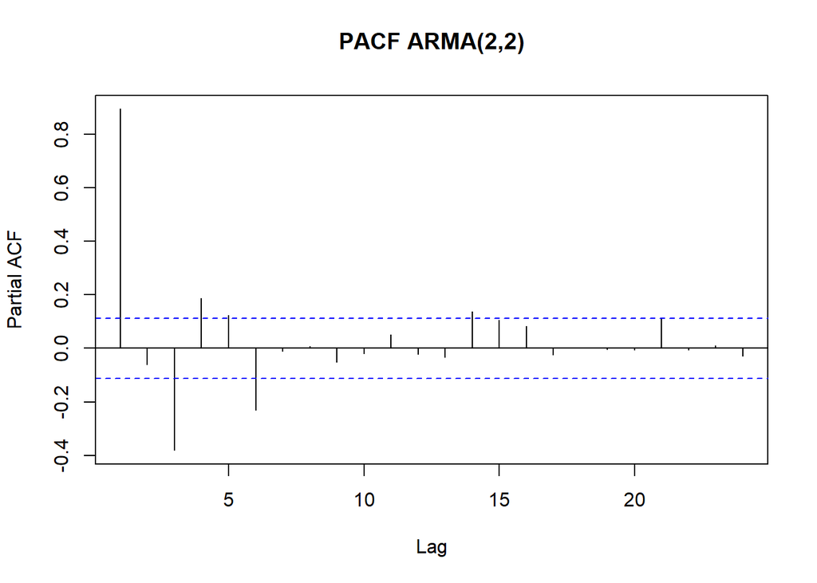

```r
pacf(arma22,
     main = "PACF ARMA(2,2)")
```

**Interpretasi:**

PACF juga cenderung **tails off**. Jadi, PACF tidak berhenti tajam pada satu lag tertentu.

## 3.7 3.7 Plot EACF

```r
TSA::eacf(arma22)
```

```
## AR/MA
##   0 1 2 3 4 5 6 7 8 9 10 11 12 13
## 0 x x x x x x x x o o o  o  o  o
## 1 o x o o o o x o o o o  o  o  o
## 2 x x o o o o x o o o o  o  o  o
## 3 x x o x o o x o o o o  o  o  o
## 4 x x x x o o x o o o o  o  o  o
## 5 x x x x x x x o o o o  o  o  o
## 6 o o x o x x o o o o o  o  o  o
## 7 o o x o x x o x o o o  o  o  o
```

**Interpretasi:**

EACF digunakan untuk membantu melihat ordo model. Pola yang dicari mengarah pada **AR(2), MA(2)**.

## 3.8 3.8 Scatterplot antar-lag

### 3.8.1 $Y_t$ dengan $Y_{t-1}$

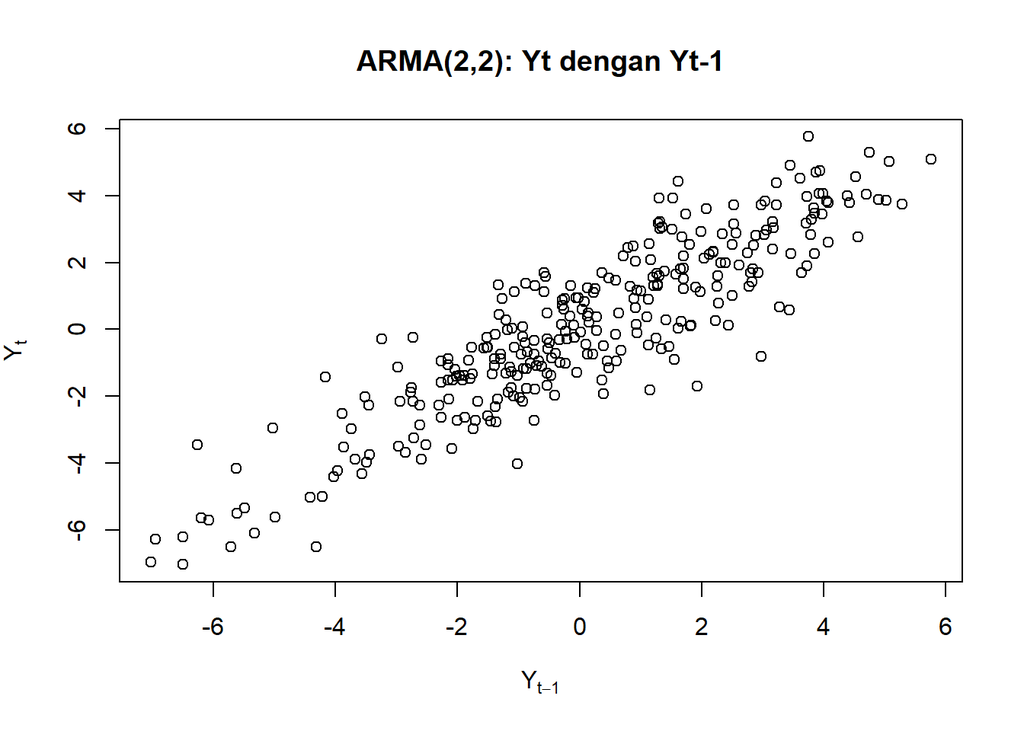

```r
yt_arma22_1 <- arma22[2:n]
yt1_arma22 <- arma22[1:(n-1)]

plot(yt1_arma22, yt_arma22_1,
     xlab = expression(Y[t-1]),
     ylab = expression(Y[t]),
     main = "ARMA(2,2): Yt dengan Yt-1")
```

### 3.8.2 $Y_t$ dengan $Y_{t-2}$

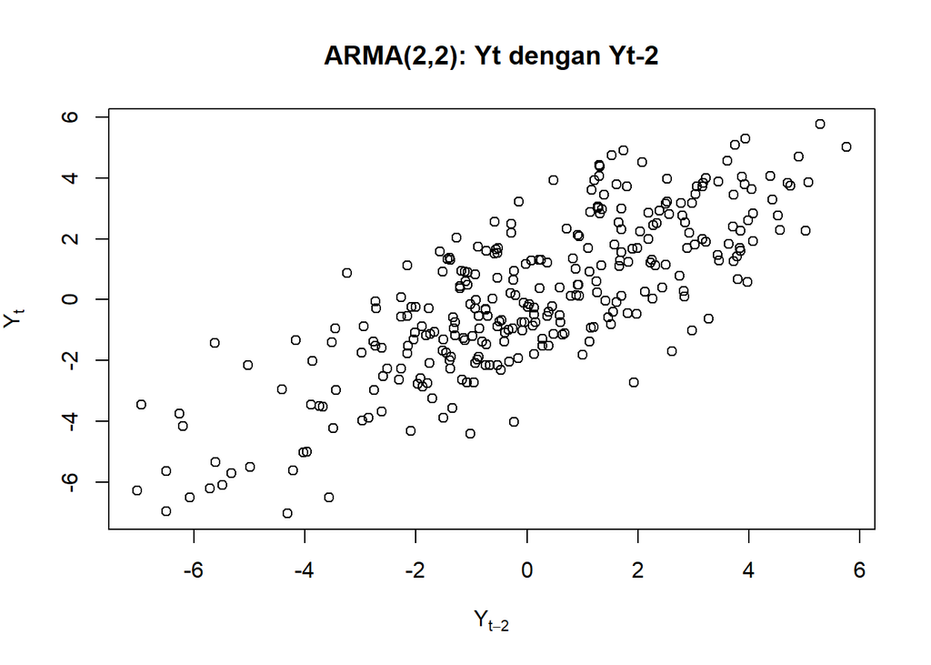

```r
yt_arma22_2 <- arma22[3:n]
yt2_arma22 <- arma22[1:(n-2)]

plot(yt2_arma22, yt_arma22_2,
     xlab = expression(Y[t-2]),
     ylab = expression(Y[t]),
     main = "ARMA(2,2): Yt dengan Yt-2")
```

### 3.8.3 $Y_t$ dengan $Y_{t-3}$

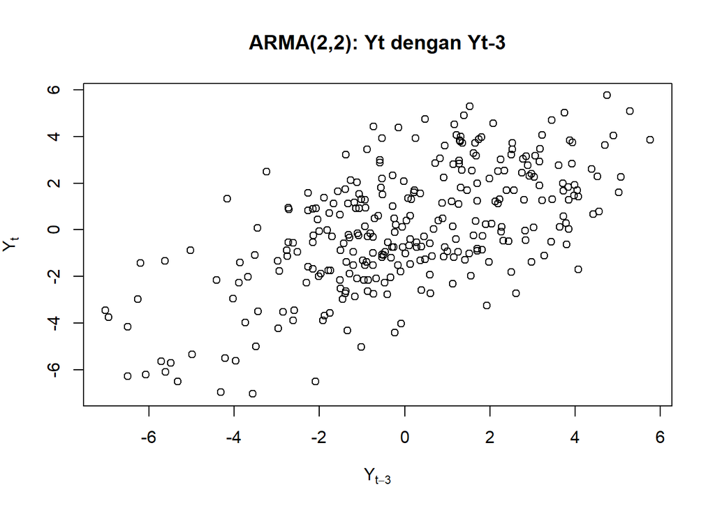

```r
yt_arma22_3 <- arma22[4:n]
yt3_arma22 <- arma22[1:(n-3)]

plot(yt3_arma22, yt_arma22_3,
     xlab = expression(Y[t-3]),
     ylab = expression(Y[t]),
     main = "ARMA(2,2): Yt dengan Yt-3")
```

**Interpretasi:**

Pada ARMA(2,2), komponen AR dan MA sama-sama membuat nilai sekarang berhubungan dengan nilai sebelumnya. Karena itu, hubungan masih bisa terlihat pada lag 1, 2, dan 3.

## 3.9 3.9 Autokorelasi hasil bangkitan

```r
rho_arma22_sim <- c(
  cor(yt_arma22_1, yt1_arma22),
  cor(yt_arma22_2, yt2_arma22),
  cor(yt_arma22_3, yt3_arma22)
)

rho_arma22_sim
```

```
## [1] 0.8946787 0.7882200 0.6177423
```

**Interpretasi:**

Nilai ini menunjukkan seberapa kuat $Y_t$ berhubungan dengan nilai sebelumnya. Karena ada komponen AR, korelasi masih bisa muncul pada lag yang lebih besar.

## 3.10 3.10 Autokorelasi teoritis ARMA(2,2)

Modul menjelaskan komponen ARMA melalui bentuk umum dan penggunaan koefisien untuk membangun komponen AR serta MA secara rekursif. Untuk memperoleh autokorelasi teoritis pada model ARMA(2,2), perhitungan berikut memperluas prinsip rekursif tersebut.

Koefisien MA tak hingga awal dihitung dari

$$\psi_0=1,$$

$$\psi_1=\phi_1+\theta_1,$$

$$\psi_2=\phi_1\psi_1+\phi_2+\theta_2,$$

dan untuk lag berikutnya

$$\psi_j=\phi_1\psi_{j-1}+\phi_2\psi_{j-2}.$$

```r
Npsi <- 10000
psi <- numeric(Npsi)

psi[1] <- 1
psi[2] <- 0.5 * psi[1] + 0.4
psi[3] <- 0.5 * psi[2] + 0.2 * psi[1] + 0.6

for(j in 4:Npsi){
  psi[j] <- 0.5 * psi[j - 1] + 0.2 * psi[j - 2]
}

gamma0 <- sum(psi^2)
gamma1 <- sum(psi[1:(Npsi - 1)] * psi[2:Npsi])
gamma2 <- sum(psi[1:(Npsi - 2)] * psi[3:Npsi])
gamma3 <- sum(psi[1:(Npsi - 3)] * psi[4:Npsi])

rho1_arma22 <- gamma1 / gamma0
rho2_arma22 <- gamma2 / gamma0
rho3_arma22 <- gamma3 / gamma0

rho_arma22_teori <- c(rho1_arma22, rho2_arma22, rho3_arma22)

round(rho_arma22_teori, 4)
```

```
## [1] 0.8592 0.7492 0.5464
```

**Interpretasi:**

Nilai ini menunjukkan pola autokorelasi secara teori. Karena ada komponen AR, autokorelasi masih dapat muncul pada lag yang lebih besar.

## 3.11 3.11 Perbandingan autokorelasi ARMA(2,2)

```r
data.frame(
  Lag = 1:3,
  Bangkitan = round(rho_arma22_sim, 4),
  Teoritis = round(rho_arma22_teori, 4)
)
```

```
##   Lag Bangkitan Teoritis
## 1   1    0.8947   0.8592
## 2   2    0.7882   0.7492
## 3   3    0.6177   0.5464
```

**Interpretasi:**

Hasil simulasi seharusnya mendekati nilai teori. Perbedaan kecil masih wajar karena data dibuat secara acak.

# 4 4. Ringkasan Perbandingan

```r
ringkasan_teori <- rbind(
  MA2 = rho_ma2_teori,
  AR2 = rho_ar2_teori,
  ARMA22 = rho_arma22_teori
)

colnames(ringkasan_teori) <- c("Lag 1", "Lag 2", "Lag 3")

round(ringkasan_teori, 4)
```

```
##         Lag 1  Lag 2  Lag 3
## MA2    0.4211 0.3947 0.0000
## AR2    0.6250 0.5125 0.3812
## ARMA22 0.8592 0.7492 0.5464
```

**Kesimpulan:**

- **MA(2):** ACF berhenti setelah lag 2, sedangkan PACF cenderung tails off.
- **AR(2):** PACF berhenti setelah lag 2, sedangkan ACF cenderung tails off.
- **ARMA(2,2):** ACF dan PACF sama-sama cenderung tails off karena model memiliki komponen AR dan MA.

Ketiga data terlihat stasioner dari plot time series karena tidak menunjukkan tren yang jelas. Secara umum, hasil simulasi juga diharapkan mendekati nilai teoritisnya.